# Homework_06

Austin Cherian

2024-10-16

## Introduction

This report examines the quality of care provided to asthma patients within the SyntheticMGUH database, focusing on data collected from October 2022 to October 2023, which is when the SyntheticMGUH database was created. Asthma is a chronic respiratory condition that significantly impacts patients’ quality of life and requires ongoing management to prevent exacerbations. According to established guidelines, effective asthma care includes the implementation of a comprehensive asthma care plan, prescription of both maintenance and rescue inhalers, and administration of the pneumococcal vaccination within the past year. This report aims to define the population of asthma patients explicitly, utilizing specific criteria to identify individuals with asthma based on their medical history and treatment records. We will analyze demographic factors such as age, gender, race, and smoking status, and evaluate the proportion of patients receiving recommended care interventions. Through this analysis, we aim to provide insights into adherence to care guidelines and identify areas for improvement in asthma management.

## Defining Asthma Patient Cohort

In this report, we define the criteria for identifying asthmatic patients based on a comprehensive analysis of prescription medications, medical diagnoses, and treatment encounters.

### Diagnosed with Asthma

First, we identify patients diagnosed with an asthma disorder, using the “conditions” table as our data source. Here, the “description” field must explicitly mention asthma, and we apply the criterion that the “stop” field is NULL, ensuring that we only consider individuals with an active diagnosis of asthma. It is worth noting that a patient cannot have both an active childhood asthma and active regular asthma diagnosis at the time.

```sql
SELECT description, COUNT(DISTINCT patient)
FROM conditions
WHERE LOWER(description) LIKE '%asthma%' AND stop IS NULL
GROUP BY description
-- checked to make sure that none of the individual patients have multiple asthma diagnoses (i.e both childhood asthma and asthma)
```

2 records

| description | count |
| --- | --- |
| Asthma | 40 |
| Childhood asthma | 312 |

From the above query, we can see that 40 patients are diagnosed with asthma, and 312 patients are diagnosed with childhood asthma.

### Asthma medications

Next, we consider patients who have been prescribed asthma medications, including both rescue and maintenance inhalers. The data for this assessment is sourced from the “medications” table, where we specifically look at the “code” field to ensure it aligns with a predetermined list of codes for maintenance and rescue inhalers. Additionally, the “reasondescription” field must explicitly indicate that the reason for the prescription is “asthma” or “childhood asthma,” thereby excluding instances where inhalers were prescribed for diagnoses such as pulmonary emphysema, chronic bronchitis, or hypoxemia. While acknowledging there is some overlap between the presentations of the aforementioned diagnoses and asthma [(1)](https://www.lung.org/lung-health-diseases/lung-disease-lookup/asthma/learn-about-asthma/types/asthma-copd-overlap-syndrome), we chose to focus on patients with distinct presentations of asthma as indicated by their “reasondescription”. Furthermore, we only include active prescriptions, which again are indicated by a “stop” field value of NULL.

```sql
SELECT reasondescription, COUNT(DISTINCT patient)
FROM medications
WHERE
  code IN (95996, 349094, 616830, 1998774, 896209, 896006, 966529, 746815, 966524, 1547660, 1998772, 1536144, 630208, 859088, 745752, 351137, 351136, 245314, 2123111, 746763)
  -- list of codes that describe both rescue and maintenance inhalers
  AND (reasondescription = 'Asthma' OR reasondescription = 'Childhood asthma')
  AND stop IS NULL
  --active prescription
GROUP BY reasondescription
```

2 records

| reasondescription | count |
| --- | --- |
| Asthma | 39 |
| Childhood asthma | 1333 |

The query shows 1333 people were prescribed inhalers for childhood asthma, and 39 people were prescribed inhalers for regular asthma.

### Encounters where patient treated for asthma

Finally, we examine the encounters table. In this context, the “reasondescription” field must contain the term “asthma,” reflecting instances where patients received treatment specifically for this condition. The “start” field for each encounter must also fall after October 2022, aligning with the lower bound of our study’s time frame.

```sql
SELECT COUNT(DISTINCT patient) as num_of_asthma_patients
FROM encounters
WHERE LOWER(reasondescription) LIKE '%asthma%'
  AND start >= '2022-10-01T00:00:00Z'
-- make sure encounters are after our study start date
```

1 records

| num_of_asthma_patients |
| --- |
| 607 |

It appears that 607 patients were treated for asthma in their encounters.

It is important to note that asthma is generally considered a lifelong disease, though symptoms may diminish in frequency or intensity over time [(2)](https://www.nhs.uk/conditions/asthma/). Our objective is to enhance the quality of care for asthma patients based on synthetic data records from the past year. Consequently, we aim to establish a cohort comprising patients with an active asthmatic condition, explicitly excluding those who are no longer prescribed asthma medications or diagnosed with an asthmatic condition. This focused approach allows for a clearer assessment of care quality among individuals currently managing asthma.

### Alive Patients

Along with the previous criteria, we want to add one more to ensure we only consider patients who are alive. We do so by making sure that the “DeathDate” field in the “patients” table is NULL. This criterion allows for a clearer assessment of care quality among individuals currently managing asthma.

```sql
SELECT deathdate, COUNT(id)
FROM patients
WHERE deathdate IS NULL
GROUP BY deathdate
-- make sure we only consider alive patients
```

1 records

| deathdate | count |
| --- | --- |
| NA | 25000 |

There are 25000 patients in the SyntheticMGUH database that are alive

### Putting it together

Having established the criteria for our cohort, we will now consolidate all these elements into a single query. The results of this query will be inserted into a temporary table named “asthmaCohort,” which will serve as the foundation for our subsequent analysis.

#### Check one row per patient

To ensure the integrity of our data set, we will first verify that each patient occupies only one row in the temporary table. This will be done by comparing the total number of rows in the table to the distinct count of patients, allowing us to confirm that there are no duplicate entries.

```sql
WITH asthma_cohort AS (
  SELECT DISTINCT patient
  FROM medications
  WHERE
    code IN (95996, 349094, 616830, 1998774, 896209, 896006, 966529, 746815, 966524, 1547660, 1998772, 1536144, 630208, 859088, 745752, 351137, 351136, 245314, 2123111, 746763)
    AND (reasondescription = 'Asthma' OR reasondescription = 'Childhood asthma')
    AND stop IS NULL
-- prescribed maintenance or rescue inhaler for asthma condition
  UNION

  SELECT DISTINCT patient
  FROM conditions
  WHERE LOWER(description) LIKE '%asthma%' AND stop IS NULL
  UNION
-- has a diagnosed asthma condition
  SELECT DISTINCT patient
  FROM encounters
  WHERE LOWER(reasondescription) LIKE '%asthma%'
    AND start >= '2022-10-01T00:00:00Z'
),

-- was treated for an asthma condition after our study's start date

alive_cohort AS (
  SELECT id, deathdate
  FROM patients
  WHERE deathdate IS NULL
),
-- defining alive patient cohort

alive_asthma_cohort AS (
  SELECT *
  FROM asthma_cohort
  INNER JOIN alive_cohort
  ON asthma_cohort.patient = alive_cohort.id
)
--using inner join to make sure we keep only alive asthma patients

SELECT COUNT(*) AS rows, COUNT(patient) AS num_of_patients
FROM alive_asthma_cohort
```

1 records

| rows | num_of_patients |
| --- | --- |
| 1250 | 1250 |

The number of rows and the number of patients are equal, so we can be confident that each patient only occupies one row.

#### Creating asthmaCohort table

We will now proceed with the creation of the “asthmaCohort” table. To ensure a clean slate, we will first drop the table if it already exists.

Following this, we will execute the previously consolidated query once more, but this time we will direct the output into the newly created “asthmaCohort” table.

```sql
DROP TABLE IF EXISTS asthmaCohort
```

```sql
WITH asthma_cohort AS (
  SELECT DISTINCT patient
  FROM medications
  WHERE
    code IN (95996, 349094, 616830, 1998774, 896209, 896006, 966529, 746815, 966524, 1547660, 1998772, 1536144, 630208, 859088, 745752, 351137, 351136, 245314, 2123111, 746763)
    AND (reasondescription = 'Asthma' OR reasondescription = 'Childhood asthma')
    AND stop IS NULL
  UNION

  SELECT DISTINCT patient
  FROM conditions
  WHERE LOWER(description) LIKE '%asthma%' AND stop IS NULL
  UNION

  SELECT DISTINCT patient
  FROM encounters
  WHERE LOWER(reasondescription) LIKE '%asthma%'
    AND start >= '2022-10-01T00:00:00Z'
),

alive_cohort AS (
  SELECT id, deathdate
  FROM patients
  WHERE deathdate IS NULL
),

alive_asthma_cohort AS (
  SELECT asthma_cohort.patient
  FROM asthma_cohort
  INNER JOIN alive_cohort
  ON asthma_cohort.patient = alive_cohort.id
)
SELECT * INTO TEMP asthmaCohort FROM alive_asthma_cohort
```

We can validate that we successfully created the table with the following query:

```sql
SELECT *
FROM asthmaCohort
LIMIT 5
```

5 records

| patient |
| --- |
| 4a7a5aa7-a044-0d2e-cc7b-032ab6b9f318 |
| 3c9f07b1-d3ce-9ad9-0669-f403c8676c1e |
| a89bf1cb-e014-0243-c671-7df0230da865 |
| 6983f831-d10b-6aea-e92a-c78398389591 |
| 42e820d3-2ec2-f851-74d3-ceb386eafbe2 |

Great! We verified that we created a table of asthma patients, and we can begin our analysis.

## Describe the asthma population

### Race

To analyze the racial distribution of asthma patients in our dataset, we will group the patients based on the “race” field in the “patients” table.

```sql
WITH rc AS (
  SELECT race, COUNT(patient) AS race_counts
  FROM asthmaCohort
  LEFT JOIN patients
  ON asthmaCohort.patient = patients.id
  GROUP BY race
)


SELECT race, race_counts*100/SUM(race_counts) OVER() AS percentage
FROM rc
```

6 records

| race | percentage |
| --- | --- |
| hawaiian | 1.04 |
| other | 0.80 |
| native | 0.56 |
| black | 48.56 |
| white | 44.32 |
| asian | 4.72 |

It appears as though the majority of the patients in our table are black (48.56%) and white (44.32%).

### Gender

To assess the gender distribution of asthma patients in our dataset, we will group the patients according to the “gender” field in the “patients” table. This method enables us to systematically categorize the data and identify the representation of different gender groups within the asthma patient population.

```sql
-- define the totals grouped by gender
WITH gc AS (
  SELECT gender, COUNT(patient) AS asthma_patient_count
  FROM asthmaCohort
  LEFT JOIN patients
  ON asthmaCohort.patient = patients.id
  GROUP BY gender
)

SELECT
  gender,
  asthma_patient_count,
  asthma_patient_count * 100/SUM(asthma_patient_count) OVER() AS percentage
FROM gc
```

2 records

| gender | asthma_patient_count | percentage |
| --- | --- | --- |
| M | 593 | 47.44 |
| F | 657 | 52.56 |

It appears that distribution of gender in our data set is split pretty evenly with males comprising 47.44% and females comprising 52.56% of the data.

### Age

What is the age distribution of the asthma patients in our data set? To calculate the ages of the patients, we will use October 1st, 2023, at 00:00:00 as the reference date. This date marks the creation of the SyntheticMGUH database and serves as the upper limit for our analysis time frame.

In addition, we will store the output as a variable, so we can visualize the age distribution in R.

```sql
SELECT EXTRACT(YEAR FROM AGE('2023-10-01T00:00:00Z', birthdate)) AS age,
       patient
FROM patients
JOIN asthmaCohort ON patients.id = asthmaCohort.patient
-- made sure there are no NULL ages from that operation
```

#### Plotting age distribution

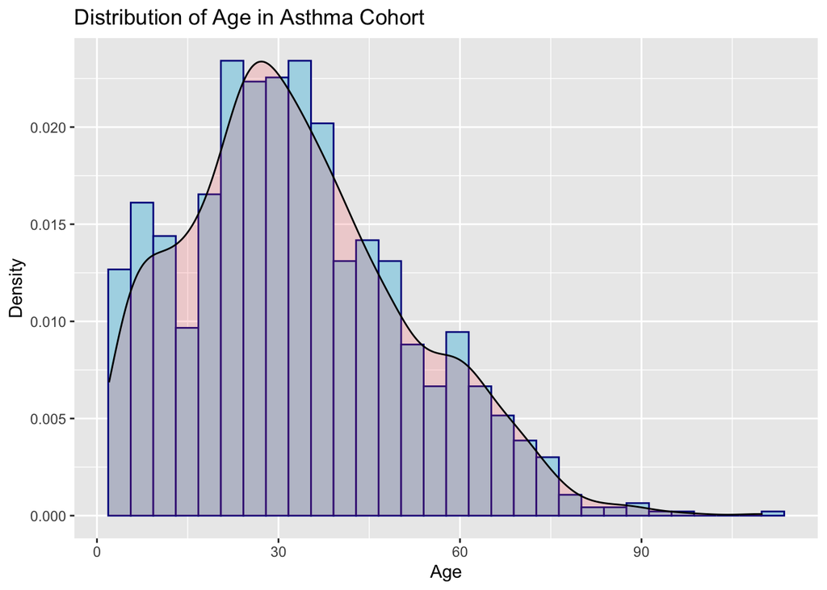

```r
ggplot(age_df, aes(x = age)) +
  geom_histogram(aes(y = ..density..), color = "darkblue", fill = "lightblue") +
  geom_density(alpha = 0.2, fill = "#FF6666") +
  xlab("Age") +
  ylab("Density") +
  labs(title = "Distribution of Age in Asthma Cohort")
```

### Smoker status

What percentage of the asthma patients in our tables are active, regular smokers? In the query below, we focus exclusively on patients who have a documented diagnosis of smoking. This means they have a condition explicitly indicating someone who smokes daily, as noted in the “description” field of the “conditions” table. Additionally, we ensure that these patients are classified as active smokers, which is confirmed by the “stop” field being NULL.

#### Checking conditions tables

```sql
SELECT code, description, COUNT(DISTINCT patient) AS smoker_count
FROM conditions
WHERE LOWER(description) LIKE '%smoke%'
-- checks for diagnosed condition related to smoking
  AND stop IS NULL
--active smoker
GROUP BY code, description
-- 449868002 is the code for "Smokes tobacco daily"
```

1 records

| code | description | smoker_count |
| --- | --- | --- |
| 449868002 | Smokes tobacco daily | 202 |

We have 202 active diagnosed smokers as indicated by the conditions table.

#### Checking encounters table

In the query below, we also examine the “encounters” table for patients who received treatment for a smoking-related condition, as indicated by the “reasondescription” field. However, we found that there were no patients who met the specified criteria for active smokers in the “encounters” table.

```sql
SELECT reasoncode, reasondescription, COUNT(DISTINCT patient)
FROM encounters
WHERE LOWER(reasondescription) LIKE '%smoke%'
GROUP BY reasoncode, reasondescription
-- no smokers in the encounters tables
```

0 records

| reasoncode | reasondescription | count |
| --- | --- | --- |

#### Calculating the percentage of smokers

Using the criteria previously established to define our smoker cohort, we will join this cohort with the asthma cohort to identify which asthma patients have a smoking status.

```sql
--create CTE with patients table plus smoking status column
WITH smoker_status AS (
  SELECT DISTINCT patient,
  CASE
    WHEN code = '449868002' AND stop IS NULL THEN 'YES'
    ELSE 'NO'
    END AS smoker_status
  FROM conditions),

sc AS (
  SELECT smoker_status, COUNT(a.patient) AS smoker_counts
  FROM asthmaCohort AS a
  LEFT JOIN smoker_status AS s
  ON a.patient = s.patient
  GROUP BY smoker_status)


SELECT smoker_status, smoker_counts*100/SUM(smoker_counts) OVER() AS percentage
FROM sc
```

2 records

| smoker_status | percentage |
| --- | --- |
| NO | 99.7605746 |
| YES | 0.2394254 |

As shown by the query above, 99.76% of the patients in our data set are not active habitual smokers while 0.24% are.

## Determine what proportion have an asthma care plan

Next, we aim to determine the proportion of the asthma cohort that has an asthma care plan. This assessment will help us evaluate whether we are providing appropriate treatment to our asthmatic patients.

To identify an asthma care plan, we created a new column called “asthma_care_plan.” This column is assigned a value of ‘Yes’ if the “description” or “reasondescription” fields contain terms related to “asthma,” and ‘No’ otherwise. Additionally, we ensure that the care plans are active by verifying that the “stop” field is NULL.

After joining the “careplans” table with the “asthmaCohort” table, we noted that there are more rows than patients, as an individual patient may have multiple care plans. To address this issue, we need to aggregate the data so that if an asthma patient has at least one asthma care plan, they will be classified as having one.

First, we will create a new column named “asthma_care_plan_final,” which will take a value of 1 if “asthma_care_plan” is ‘Yes’ and 0 if it is ‘No.’ Next, we will aggregate the data using the MAX() function, ensuring that if there is at least one asthma care plan among a patient’s records, only that plan is retained.

From this aggregated data, we can then calculate the percentage of asthma patients who have an asthma care plan, as well as the percentage of those who do not.

```sql
WITH asthma_care_plan AS (
  SELECT DISTINCT a.patient, cp.description, cp.reasondescription,
    CASE
      WHEN (LOWER(cp.description) LIKE '%asthma%' OR LOWER(cp.reasondescription) LIKE '%asthma%') THEN 'Yes'
      ELSE 'No'
    END AS asthma_care_plan
--checks for care plan related to asthma
  FROM asthmaCohort AS a
  LEFT JOIN careplans AS cp ON a.patient = cp.patient
  WHERE cp.stop IS NULL
-- active care plan
--it's ok in this case if the where clause is executed after the join
),

cpc AS (
SELECT
  COUNT(DISTINCT patient) AS total_patients,
  MAX(CASE WHEN asthma_care_plan = 'Yes' THEN 1 ELSE 0 END) AS asthma_care_plan_final
FROM asthma_care_plan
)
--have to aggregate rows so only one row per patient
-- for each patient, if at least one careplan meets the criteria of being an asthma care plan, then only that row is kept using the MAX() function

SELECT
  CASE WHEN asthma_care_plan_final = 1 THEN 'Yes'
       WHEN asthma_care_plan_final = 0 THEN 'No'
-- converting the binary values back to categorical
  END AS has_asthma_care_plan,
  total_patients * 100/SUM(total_patients) OVER() AS percentage
FROM cpc
```

1 records

| has_asthma_care_plan | percentage |
| --- | --- |
| Yes | 100 |

The percentage of asthma patients that have an asthma care plan is 100%, which is great news!

## Determine what proportion have a maintenance and rescue inhaler

To determine the proportion of our asthma patient cohort that have a maintenance or rescue inhaler, we will break this analysis down into specific categories: those with only a rescue inhaler, those with only a maintenance inhaler, those with both, and those with neither.

Both maintenance and rescue inhalers are defined by predetermined sets of codes in the “code” field of the “medications” table. We will begin by joining the “asthmaCohort” table with the medications table.

Given that a single patient may have multiple medications, it is essential to aggregate this data effectively. For maintenance inhalers, we will create a new column named “has_maintenance.” If a medication meets the criteria for a maintenance inhaler, this column will be assigned a value of 1; otherwise, it will be assigned a value of 0. We will then apply the MAX() function to the “has_maintenance” column to consolidate records, ensuring that we capture only whether a patient has been prescribed at least one maintenance inhaler.

We will follow a similar process for rescue inhalers, creating a new column called “has_rescue” and applying the MAX() function to aggregate records of patients who may have multiple prescribed rescue inhalers.

Subsequently, we will create another common table expression with a new column called “which_meds.” In this column, if “has_rescue” equals 0 and “has_maintenance” equals 1, the value will be “maintenance.” If “has_rescue” equals 1 and “has_maintenance” equals 0, the value will be “rescue.” If both columns have a value of 1, then “which_meds” will be labeled “both.” Finally, if both columns are 0, “which_meds” will be classified as “neither.”

From this aggregated data, we can calculate the percentage of asthma patients in each of the categories: “maintenance,” “rescue,” “both,” and “neither.”

```sql
WITH asthma_meds AS (
  SELECT a.patient, m.code, m.description
  FROM asthmaCohort AS a
  LEFT JOIN medications AS m ON a.patient = m.patient
),

categorized_meds AS (
   SELECT patient,
    MAX(CASE WHEN code IN (95996, 349094, 616830, 1998774, 896209, 896006, 966529, 746815, 966524, 1547660, 1998772, 1536144) THEN 1 ELSE 0 END) AS has_maintenance,
    --aggregates all the maintenance inhaler rows
    MAX(CASE WHEN code IN (630208, 859088, 745752, 351137, 351136, 245314, 2123111, 746763) THEN 1 ELSE 0 END) AS has_rescue
    --aggregates all the rescue inhaler rows
  FROM asthma_meds
  GROUP BY patient
),

further_categorized_meds AS (
SELECT DISTINCT patient,
  CASE
    WHEN has_rescue = 0 AND has_maintenance = 1 THEN 'maintenance'
    WHEN has_rescue = 1 AND has_maintenance = 0 THEN 'rescue'
    WHEN has_rescue = 1 AND has_maintenance = 1 THEN 'both'
    WHEN has_rescue = 0 AND has_maintenance = 0 THEN 'neither'
  END AS which_meds
FROM categorized_meds
),

cmc AS (
SELECT COUNT(DISTINCT patient) AS asthma_patient_count, which_meds
FROM further_categorized_meds
GROUP BY which_meds)


SELECT
  which_meds,
  asthma_patient_count * 100.0 / SUM(asthma_patient_count) OVER () AS percentage
FROM cmc
```

3 records

| which_meds | percentage |
| --- | --- |
| both | 25.60 |
| neither | 0.08 |
| rescue | 74.32 |

The resulting query reveals that in our asthma cohort, 74.32% of patients possess a rescue inhaler, 25.60% have both a rescue and a maintenance inhaler, and 0.08% of patients fall into the category of having neither inhaler.

Interestingly, there is no category for patients with only a maintenance inhaler, as all individuals prescribed a maintenance inhaler in our data set were also found to have a rescue inhaler. However, it is important to note that the reverse case is not necessarily true.

## Determine what proportion of patients have received the vaccination in the preceding 12 months

To determine the proportion of patients in our “asthmaCohort” table who have received the pneumococcal vaccination in the past 12 months, we will begin by clearly defining the relevant conditions within our SyntheticMGUH database.

We will join the “asthmaCohort” table with the “immunizations” data table. However, we encounter a familiar challenge: a single patient may have multiple immunizations. To address this, we need to categorize each immunization based on two specific criteria: whether it is a pneumococcal vaccination and whether it was administered within the last 12 months.

For the first criterion, we will create a new column named “has_vacc.” If the “description” field of an immunization record contains ‘Pneumococcal conjugate PCV 13,’ this column will be assigned a value of ‘Yes’; otherwise, it will be ‘No.’ For the second criterion, we will introduce another column called “within_12.” This column will contain the value ‘Yes’ if the duration between the “start” date of the immunization (when immunization was taken) and the reference date of October 1, 2023 (the upper bound of our study) is less than 12 months; otherwise, it will be ‘No.’

After labeling our criteria, we need to convert these values into a binary format for aggregation. In a new column, “has_vacc_within_12,” an immunization will receive a value of 1 if both “has_vacc” and “within_12” are ‘Yes,’ and 0 otherwise.

Finally, we will apply the MAX() function to the “has_vacc_within_12” column to consolidate the records, ensuring that if a patient has received at least one immunization that meets our defined criteria, then only that record is retianed.

```sql
WITH asthma_vacc AS (
  SELECT
    DISTINCT a.patient AS asthma_patient,
    CASE
      WHEN description = 'Pneumococcal conjugate PCV 13' THEN 'Yes'
      ELSE 'No'
    END AS has_vacc,
-- label the pneumoccocal vaccine
    CASE
      WHEN (EXTRACT(Year FROM AGE('2023-10-01T00:00:00Z', date)) * 12 + EXTRACT(Month FROM AGE('2023-10-01T00:00:00Z', date))) <= 12 THEN 'Yes'
      ELSE 'No'
    END AS within_12
--label taking any vaccine within 12 months
  FROM asthmaCohort AS a
  LEFT JOIN immunizations AS i
  ON a.patient = i.patient),

agg_asthma_vacc AS (
SELECT
  DISTINCT asthma_patient,
  MAX(CASE
        WHEN (has_vacc = 'Yes' AND within_12 = 'Yes') then 1
        ELSE 0
      END) AS has_vacc_within_12
FROM asthma_vacc
GROUP BY asthma_patient),
--aggregates data according to whether the immunization fufills the criteria of being the pneumoccocal vaccine and being taken in the last 12 months

avc AS (
  SELECT
    CASE
      WHEN has_vacc_within_12 = 1 THEN 'Yes'
      WHEN has_vacc_within_12 = 0 THEN 'No'
-- converting binary balues back to categorical
    END AS has_vacc_within_last_year,
    COUNT(asthma_patient) as asthma_patient_count
  FROM agg_asthma_vacc
  GROUP BY has_vacc_within_12)

SELECT has_vacc_within_last_year, asthma_patient_count * 100/ SUM(asthma_patient_count) OVER() AS percentage
FROM avc
```

2 records

| has_vacc_within_last_year | percentage |
| --- | --- |
| No | 99.76 |
| Yes | 0.24 |

The resulting query reveals that in our asthma cohort, 0.24% of patients did receive a pneumococcal vaccination in the last 12 months, and 99.76% did not. This finding exposes an area of patient care for asthma patients that can be improved upon.

## References

1. American Lung Association. Asthma-COPD Overlap Syndrome (ACOS) [Internet]. Lung.org. ; 2023 [cited 2024 Oct 18]. Available from: https://www.lung.org/lung-health-diseases/lung-disease-lookup/asthma/learn-about-asthma/types/asthma-copd-overlap-syndrome
2. NHS website. Asthma [Internet]. nhs.uk. 2017 [cited 2024 Oct 18]. Available from: https://www.nhs.uk/conditions/asthma/